# Pharmacokinetic-pharmacodynamic models for time courses of antibiotic effects

# About this database

This is the work of Iris Minichmayr, Vincent Aranzana-Climent and Lena Friberg from the Pharmacometrics research group at Uppsala University.

Minichmayr IK, Aranzana-Climent V, Friberg LE, PPharmacokinetic-pharmacodynamic models for time courses of antibiotic effects, In manuscript, 2022.

The database presented in this page is dynamic in nature, it will be updated regularly by the authors. If you want to be kept up to date please follow the attached github repository https://github.com/atb-models-review/atb-models-review.github.io

Search last updated : September 2021

# How to read this table

In the default view, you will see a summary table with the same format as Table S1.  
It is searchable using the search field in the top right corner of the table.  
The table is paginated and by default 10 articles are shown.  
If you want detailed information about the drugs, pathogens and/or models included in one article you can click on the green plus sign at the beginning of each row. Here follows information about what is in each detailed table :

1. Drug characteristics:
   - Drug class: Self-explanatory
   - Drug: Self-explanatory
2. Pathogen characteristics:
   - Pathogen(s): Full name of the pathogen(s) investigated
   - Number of strains: How many strains were used to produce the data the model
3. Growth model characteristics:
   - Growth model: Can comprise: 1, 2 or 3 metabolic states, growing and resting bacteria, 2-state life-cycle model, or other form
   - Growth equation: Equation characterizing the growth rate
   - Delay in growth: Does the growth rate equation describe any delay?
   - Comments: Any additional information
4. Effect model characteristics:
   - Effect equation: Does the equation link drug concentrations to effect via a linear, linear with power, Emax or sigmoid Emax model?
   - Effect on death or growth: Is the drug effect implemented as a reduction of growth or an increase in death rate?
   - Delay in effect: Does the effect equation include any delay component?
   - Drug: Name of the drug causing the effect
   - Pathogen: Full name of the studied pathogen
   - Comments: Any additional information
5. Regrowth model characteristics:
   - Regrowth model: Type of regrowth model included in the paper *e.g.* adaptive resistance, subpopulations, other
   - Comments: Any additional information
6. Interaction model characteristics:
   - Interaction model: type of interaction model *e.g.* additivity, Loewe additivity, Bliss independence, Greco model, Other
   - Interaction effect: Parametrization of the interaction effect
   - Perpetrator: Which drug affect the effect of the other drug? (concept by Wicha *et al.*, 2017)
   - Victim: Which drug effect is affected by the other drug? (concept by Wicha *et al.*, 2017)
   - Comments: Any additional information
7. PK data characteristics:
   - Patient population: Patient population underlying the PK parameters used in the publication?
   - Used for?: Were the PK parameters used as the basis for the kill-curve (dynamic) experiments or for simulations of expected bacterial densities using the final PKPD model?
   - Comments: Any additional information

|  |  | Article | Link | Drug | Pathogen | Type of experiment | Growth model | Effect equation | Regrowth model | Interaction model | Human PK | drugs_subtable | pathogens_subtable | growth_subtable | effect_subtable | resistance_subtable | interaction_subtable | pk_subtable |
| --- | --- | --- | --- | --- | --- | --- | --- | --- | --- | --- | --- | --- | --- | --- | --- | --- | --- | --- |
| 3102718 | &oplus; | Zhi et al., 1986 (3102718) | Link | Piperacillin | P.aeruginosa | D | 1 metabolic state | Emax | No regrowth model | - | - | [{'Drug class': 'Beta-lactams/penicillins', 'Drug': 'Piperacillin'}] | [{'Pathogen(s)': 'Pseudomonas aeruginosa', 'Number of strains': '-'}] | [{'Growth model': '1 metabolic state', 'Growth equation': 'Exponential growth', 'Delay in growth': 'No delay', 'Comments': '-'}] | [{'Effect equation': 'Emax', 'Effect on death or growth': 'Death', 'Delay in effect': 'No', 'Drug': 'Piperacillin', 'Pathogen': 'Pseudomonas aeruginosa', 'Comments': '-'}] | [{'Resistance model': 'No regrowth model', 'Comments': '-'}] | [{'Interaction model': '-', 'Interaction effect': '-', 'Perpetrator': '-', 'Victim': '-', 'Comments': '-'}] | [{'Patient population': '-', 'Used for?': '-', 'Comments': '-'}] |
| 3193364 | &oplus; | Zhi et al., 1988 (3193364) | Link | Piperacillin | P.aeruginosa | A | 1 metabolic state | Emax | No regrowth model | - | - | [{'Drug class': 'Beta-lactams/penicillins', 'Drug': 'Piperacillin'}] | [{'Pathogen(s)': 'Pseudomonas aeruginosa', 'Number of strains': '2'}] | [{'Growth model': '1 metabolic state', 'Growth equation': 'Logistic growth', 'Delay in growth': 'No delay', 'Comments': '-'}] | [{'Effect equation': 'Emax', 'Effect on death or growth': 'Death', 'Delay in effect': 'No delay', 'Drug': 'Piperacillin', 'Pathogen': 'Pseudomonas aeruginosa', 'Comments': '-'}] | [{'Resistance model': 'No regrowth model', 'Comments': '-'}] | [{'Interaction model': '-', 'Interaction effect': '-', 'Perpetrator': '-', 'Victim': '-', 'Comments': '-'}] | [{'Patient population': '-', 'Used for?': '-', 'Comments': '-'}] |
| 7965677 | &oplus; | Li et al., 1994 (7965677) | Link | Amoxicillin, Benzylpenicillin, Cephalexin | E.coli | S | 1 metabolic state | Emax | Subpopulations | - | - | [{'Drug class': 'Beta-lactams/penicillins', 'Drug': 'Amoxicillin'}, {'Drug class': 'Beta-lactams/penicillins', 'Drug': 'Benzylpenicillin'}, {'Drug class': 'Cephalosporins (1st gen.)', 'Drug': 'Cephale… | [{'Pathogen(s)': 'Escherichia coli', 'Number of strains': '1'}] | [{'Growth model': '1 metabolic state', 'Growth equation': 'Exponential growth', 'Delay in growth': 'No delay', 'Comments': '-'}] | [{'Effect equation': 'Emax', 'Effect on death or growth': 'Death', 'Delay in effect': 'No delay', 'Drug': 'Amoxicillin', 'Pathogen': 'Escherichia coli', 'Comments': 'concentration centered on minimal … | [{'Resistance model': 'Subpopulations', 'Comments': '-'}] | [{'Interaction model': '-', 'Interaction effect': '-', 'Perpetrator': '-', 'Victim': '-', 'Comments': '-'}] | [{'Patient population': '-', 'Used for?': '-', 'Comments': '-'}] |
| 8668686 | &oplus; | Nolting et al., 1996 (8668686) | Link | Piperacillin | E.coli | StepDil | 1 metabolic state | Emax | No regrowth model | - | - | [{'Drug class': 'Beta-lactams/penicillins', 'Drug': 'Piperacillin'}] | [{'Pathogen(s)': 'Escherichia coli', 'Number of strains': '1'}] | [{'Growth model': '1 metabolic state', 'Growth equation': 'Exponential growth', 'Delay in growth': 'Delay', 'Comments': '-'}] | [{'Effect equation': 'Emax', 'Effect on death or growth': 'Death', 'Delay in effect': 'Delay', 'Drug': 'Piperacillin', 'Pathogen': 'Escherichia coli', 'Comments': '-'}] | [{'Resistance model': 'No regrowth model', 'Comments': '-'}] | [{'Interaction model': '-', 'Interaction effect': '-', 'Perpetrator': '-', 'Victim': '-', 'Comments': '-'}] | [{'Patient population': '-', 'Used for?': '-', 'Comments': '-'}] |
| 8837524 | &oplus; | Berg et al., 1996 (8837524) | Link | Imipenem | P.aeruginosa | S | S-systems (linear approximation in log space) | other | No regrowth model | - | - | [{'Drug class': 'Carbapenems', 'Drug': 'Imipenem'}] | [{'Pathogen(s)': 'Pseudomonas aeruginosa', 'Number of strains': '1'}] | [{'Growth model': 'S-systems (linear approximation in log space)', 'Growth equation': '-', 'Delay in growth': '-', 'Comments': '-'}] | [{'Effect equation': 'other', 'Effect on death or growth': '-', 'Delay in effect': 'No delay', 'Drug': 'Imipenem', 'Pathogen': 'Pseudomonas aeruginosa', 'Comments': 'Multiplicative terms of the form (… | [{'Resistance model': 'No regrowth model', 'Comments': '-'}] | [{'Interaction model': '-', 'Interaction effect': '-', 'Perpetrator': '-', 'Victim': '-', 'Comments': '-'}] | [{'Patient population': '-', 'Used for?': '-', 'Comments': '-'}] |
| 8891135 | &oplus; | Li et al., 1996 (8891135) | Link | Amoxicillin, Ampicillin, Benzylpenicillin, Oxacillin, Dicloxacillin | E.coli | S | 1 metabolic state | Emax | No regrowth model | - | - | [{'Drug class': 'Beta-lactams/penicillins', 'Drug': 'Amoxicillin'}, {'Drug class': 'Beta-lactams/penicillins', 'Drug': 'Ampicillin'}, {'Drug class': 'Beta-lactams/penicillins', 'Drug': 'Benzylpenicill… | [{'Pathogen(s)': 'Escherichia coli', 'Number of strains': '1'}] | [{'Growth model': '1 metabolic state', 'Growth equation': 'Exponential growth', 'Delay in growth': 'No delay', 'Comments': '-'}] | [{'Effect equation': 'Emax', 'Effect on death or growth': 'Death', 'Delay in effect': 'Delay', 'Drug': 'Amoxicillin', 'Pathogen': 'Escherichia coli', 'Comments': '-'}, {'Effect equation': 'Emax', 'Eff… | [{'Resistance model': 'No regrowth model', 'Comments': '-'}] | [{'Interaction model': '-', 'Interaction effect': '-', 'Perpetrator': '-', 'Victim': '-', 'Comments': '-'}] | [{'Patient population': '-', 'Used for?': '-', 'Comments': '-'}] |
| 9087479 | &oplus; | Mouton et al., 1997 (9087479) | Link | Ceftazidime | P.aeruginosa | S | 1 metabolic state | sEmax | Adaptive resistance | - | - | [{'Drug class': 'Cephalosporins (3rd gen.)', 'Drug': 'Ceftazidime'}] | [{'Pathogen(s)': 'Pseudomonas aeruginosa', 'Number of strains': '3'}] | [{'Growth model': '1 metabolic state', 'Growth equation': 'Logistic growth', 'Delay in growth': 'Delay', 'Comments': '-'}] | [{'Effect equation': 'sEmax', 'Effect on death or growth': 'Death', 'Delay in effect': 'No delay', 'Drug': 'Ceftazidime', 'Pathogen': 'Pseudomonas aeruginosa', 'Comments': '-'}] | [{'Resistance model': 'Adaptive resistance', 'Comments': '-'}] | [{'Interaction model': '-', 'Interaction effect': '-', 'Perpetrator': '-', 'Victim': '-', 'Comments': '-'}] | [{'Patient population': '-', 'Used for?': '-', 'Comments': '-'}] |
| 9758673 | &oplus; | Yano et al., 1998 (9758673) | Link | S-4661, Meropenem, Imipenem, Cefpirome, Ceftazidime | E.coli, P.aeruginosa, S.aureus | S | 2 metabolic states | Emax | Subpopulations | - | - | [{'Drug class': 'Carbapenems', 'Drug': 'S-4661'}, {'Drug class': 'Carbapenems', 'Drug': 'Meropenem'}, {'Drug class': 'Carbapenems', 'Drug': 'Imipenem'}, {'Drug class': 'Cephalosporins (4th gen.)', 'Dr… | [{'Pathogen(s)': 'Escherichia coli', 'Number of strains': '1'}, {'Pathogen(s)': 'Pseudomonas aeruginosa', 'Number of strains': '1'}, {'Pathogen(s)': 'Staphylococcus aureus', 'Number of strains': '1'}] | [{'Growth model': '2 metabolic states', 'Growth equation': 'Logistic growth', 'Delay in growth': 'No delay', 'Comments': '-'}] | [{'Effect equation': 'Emax', 'Effect on death or growth': 'Death', 'Delay in effect': 'Delay', 'Drug': 'S-4661', 'Pathogen': 'Escherichia coli', 'Comments': '-'}, {'Effect equation': 'Emax', 'Effect o… | [{'Resistance model': 'Subpopulations', 'Comments': '-'}] | [{'Interaction model': '-', 'Interaction effect': '-', 'Perpetrator': '-', 'Victim': '-', 'Comments': '-'}] | [{'Patient population': '-', 'Used for?': '-', 'Comments': '-'}] |
| 11062192 | &oplus; | Delacher et al., 2000 (11062192) | Link | Ciprofloxacin | P.aeruginosa | StepDil | 1 metabolic state | Emax | No regrowth model | - | - | [{'Drug class': 'Quinolones', 'Drug': 'Ciprofloxacin'}] | [{'Pathogen(s)': 'Pseudomonas aeruginosa', 'Number of strains': '3'}] | [{'Growth model': '1 metabolic state', 'Growth equation': 'Exponential growth', 'Delay in growth': 'No delay', 'Comments': '-'}] | [{'Effect equation': 'Emax', 'Effect on death or growth': 'Death', 'Delay in effect': 'No delay', 'Drug': 'Ciprofloxacin', 'Pathogen': 'Pseudomonas aeruginosa', 'Comments': '-'}] | [{'Resistance model': 'No regrowth model', 'Comments': '-'}] | [{'Interaction model': '-', 'Interaction effect': '-', 'Perpetrator': '-', 'Victim': '-', 'Comments': '-'}] | [{'Patient population': '-', 'Used for?': '-', 'Comments': '-'}] |
| 12865415 | &oplus; | Jumbe et al., 2003 (12865415) | Link | Levofloxacin | P.aeruginosa | A | 1 metabolic state | sEmax | Subpopulations | - | Nosocomial pneumonia patients - Simulations | [{'Drug class': 'Quinolones', 'Drug': 'Levofloxacin'}] | [{'Pathogen(s)': 'Pseudomonas aeruginosa', 'Number of strains': '1'}] | [{'Growth model': '1 metabolic state', 'Growth equation': 'Logistic growth', 'Delay in growth': 'No delay', 'Comments': '-'}] | [{'Effect equation': 'sEmax', 'Effect on death or growth': 'Death', 'Delay in effect': 'No delay', 'Drug': 'Levofloxacin', 'Pathogen': 'Pseudomonas aeruginosa', 'Comments': '-'}] | [{'Resistance model': 'Subpopulations', 'Comments': '-'}] | [{'Interaction model': '-', 'Interaction effect': '-', 'Perpetrator': '-', 'Victim': '-', 'Comments': '-'}] | [{'Patient population': 'Nosocomial pneumonia patients', 'Used for?': 'Simulations', 'Comments': '-'}] |

[output cut: 122 more lines]

# Graphs

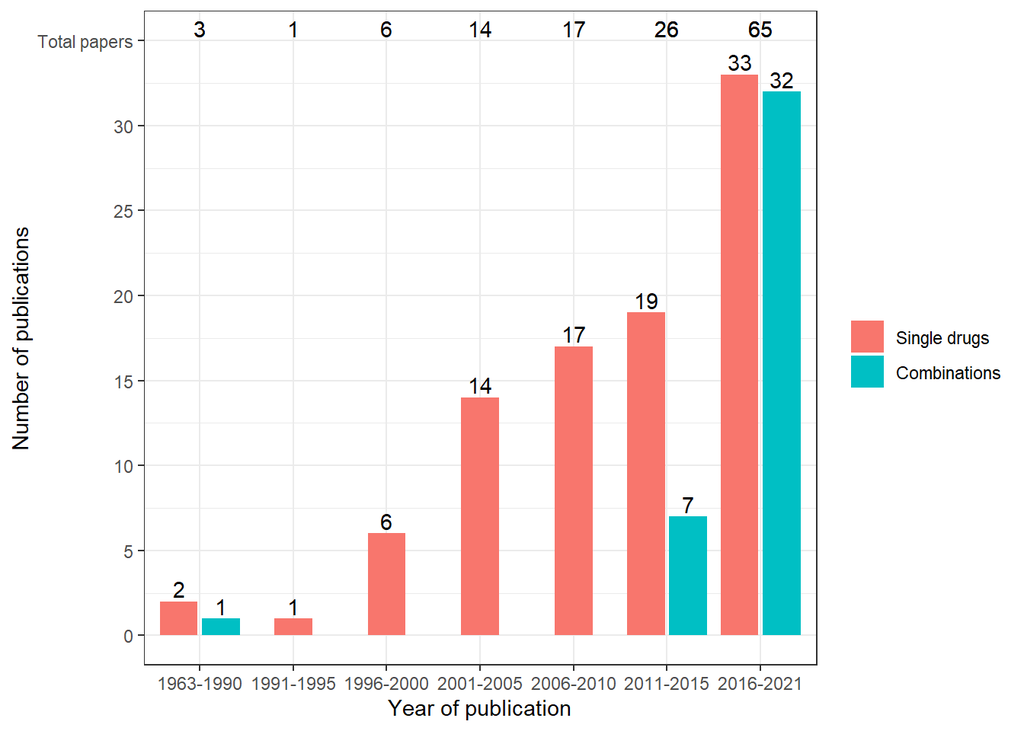

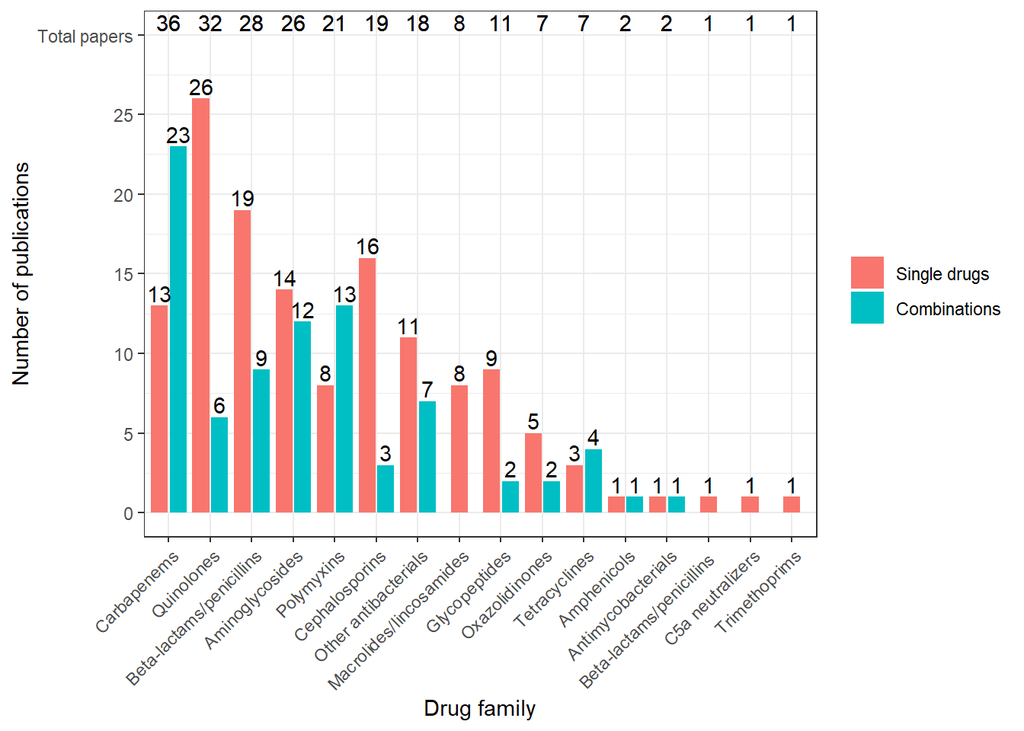

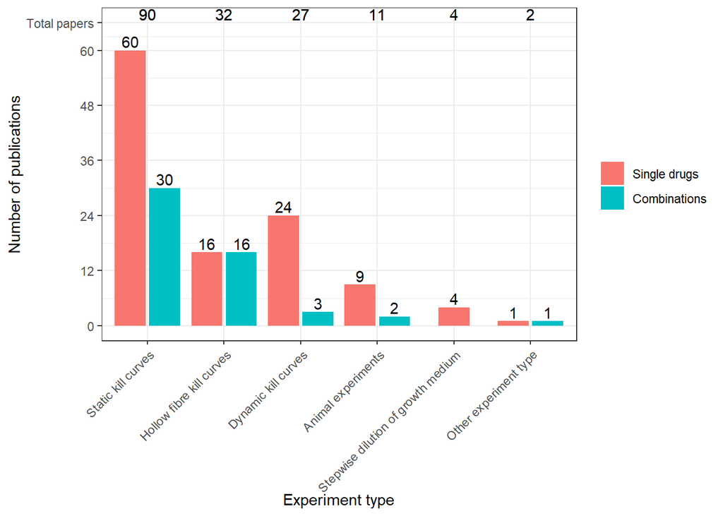

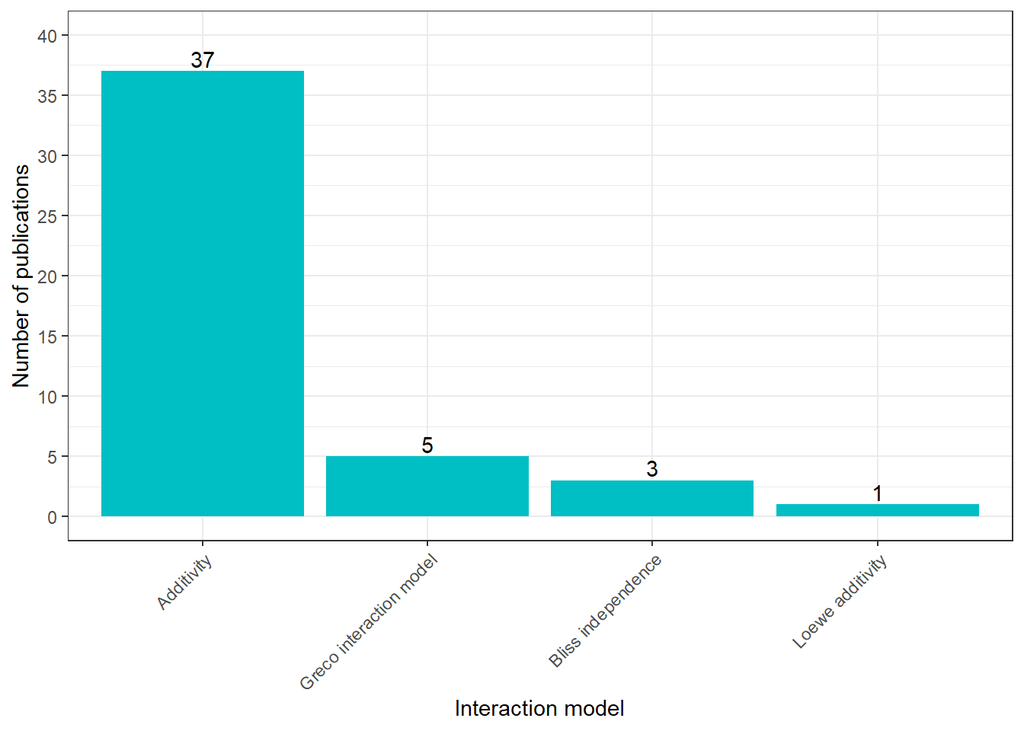

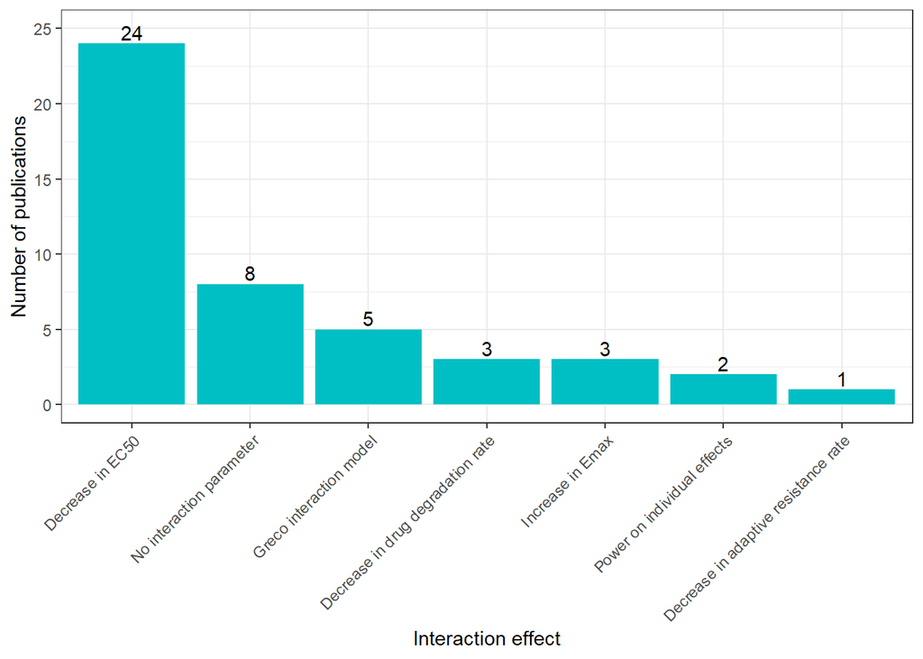